# A3: SPL Library Checkouts

## Project title

Trend of the checkouts number over time

### Authors

- Qin Deng, qdeng2@uw.edu

### Date

Libraries have always played a vital role in society by providing access to information and resources for individuals to improve their education, skills, and knowledge. With the increasing digitization of books and other resources, libraries have been adapting to new trends in borrowing and lending. The Monthly Item Borrowing Trends data from the library provides valuable insights into how patrons interact with the library’s collection. This data includes information on the monthly borrowing trends of various items, including print books, audio books, eBooks, and more, from 2017 to 2023. Analyzing this data can help library administrators and staff better understand patrons’ borrowing habits, identify popular and less popular items, and plan for future acquisitions and services. In this project, I will use R programming language to analyze this data, visualize trends over time, and gain insights into borrowing patterns. And I calculate the data of LW_avg_checkout, JE_avg_checkout, JE_max_year, LM_max_year and EB_max_year.

I will analyze the checkout times in our group project. I am going to create some data visualization to help people compare and contrast data. Here are the questions that my project can answer. - What is the average checkout number for Little Women? - What is the average checkout number for Jane Eyre? - What is the year has the highest checkout number for Jane Eyre? - What is the year has the highest checkout number for Little Women? - What is the year has the highest checkout number for e-books?

### Summary Information

```
##   UsageClass MaterialType CheckoutMonth CheckoutYear Checkouts
## 1    Digital        EBOOK             8         2017        13
## 2   Physical         BOOK             8         2017        23
## 3    Digital        MUSIC             1         2017        33
## 4    Digital     MAGAZINE             1         2017        76
## 5    Digital        MOVIE             1         2017        20
## 6    Digital        EBOOK             1         2017        30
##                                                                                  Title
## 1                                                                         Among Others
## 2 Biscuit feeds the pets / story by Alyssa Satin Capucilli ; pictures by Pat Schories.
## 3                                                                            24K Magic
## 4                                                                              Outside
## 5                                                           The Men Who Stare at Goats
## 6                                                                       Modern Romance
##                                                                                                                                                             Subjects
## 1                                                                                                                                           Fiction, Science Fiction
## 2 Pet shops Juvenile fiction, Dogs Juvenile fiction, Animals Infancy Juvenile fiction, Pet shops Fiction, Helpfulness Fiction, Dogs Fiction, Animals Infancy Fiction
## 3                                                                                                                                                      Pop, R&B/Soul
## 4
## 5                                                                                                                                            Comedy, Spoofs & Satire
## 6                                                                                                  Family & Relationships, Humor (Nonfiction), Nonfiction, Sociology
##                          Creator
## 1                      Jo Walton
## 2 Capucilli, Alyssa Satin, 1957-
## 3
## 4
## 5
## 6                    Aziz Ansari
```

```
## [1] 12.7
```

```
## [1] 14.60465
```

```
## [1] 2021
```

```
## [1] 2020
```

```
## [1] 25.13426
```

```
## [1] 2022
```

```
## Average number of checkouts per year:
```

```
##   CheckoutYear Checkouts
## 1         2017  22.24620
## 2         2018  23.39828
## 3         2019  23.58059
## 4         2020  25.27756
## 5         2021  23.53873
## 6         2022  23.50151
## 7         2023  24.46290
```

```
## [1] "BOOK"
```

The first data I studied is the average checkout number for Little Women, which is the 12.7 times. In the meantime, I also calculate the average number of Jane Eyre, which is the 14.6046512times. The reason I made them the subject of my research is that they share the same subject matter about the Feminist. And also I think the reason that Jane Eyre has a larger average checkout number is because the Jane Eyre movie aired and made people want to read the original book. Therefore I think it is good for us to compare them together. The third and forth values are about the year has the highest checkout number for Jane Eyre and Little Women, which are 2021 and 2020. I believe these two statistics prove that more and more people are taking Woman’s Rights seriously and want to read books about them to learn more about them. The last value is the year has the highest checkout number for e-books, which is 2022. I believe this trend can be attributed, in part, to the COVID-19 pandemic, which made it difficult for people to physically visit libraries. E-books offer a convenient and safe alternative that allows people to read from the comfort of their own homes, contributing to their growing popularity.

### The Dataset

The Seattle Public Library has provided valuable data on the physical and electronic book checkouts. This data was collected through the library’s circulation system, which automatically records the number of checkouts for each object. The primary purpose of the data is to keep track of the total amount and dates of checked books and to inform collection development decisions and initiatives aimed at promoting literacy and information access. The dataset contains 42.2M rows and 12 columns, providing extensive information on various categories of books and their circulation dates.

However, working with this data requires careful consideration of ethical concerns. The data may contain information about the checkout histories of specific customers, which raises privacy concerns. To protect individuals’ privacy, the data must be anonymized before analysis. Moreover, there is a risk of drawing inferences or perpetuating stereotypes based on the materials most commonly borrowed, which should be avoided.

Despite its significance, the data also has some limitations. It only includes information on checkouts from the Seattle Library system and does not cover other libraries or reading material sources. This means that the findings from this data may not be representative of the wider population’s reading habits.

### First Trends Over Time Chart

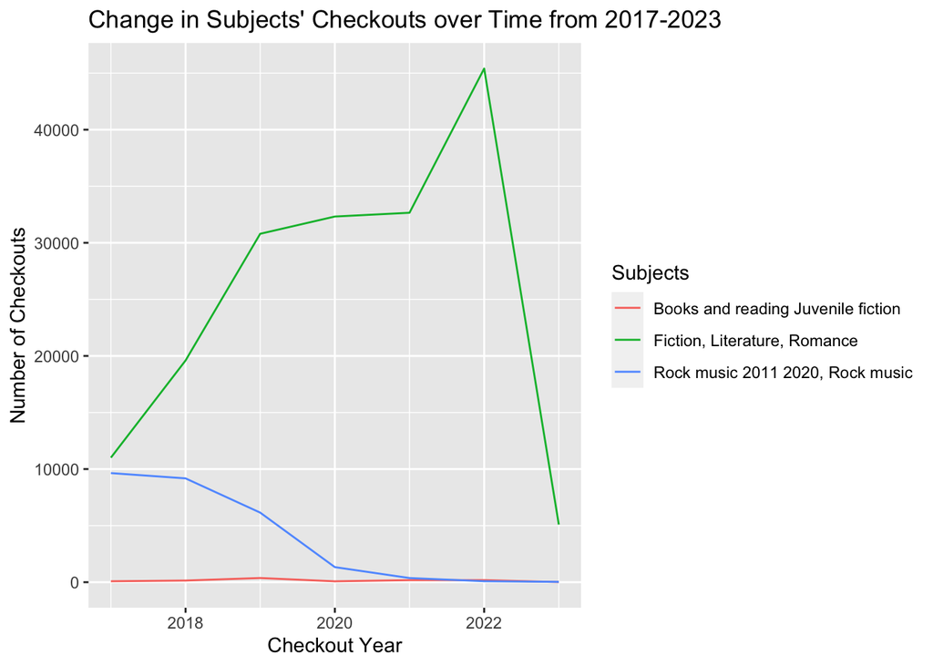

According to the graph, we can see “Fiction, Literature, Romance” has a larger amount of checkouts than others. Therefore, we can conclude that people prefer to read articles of Fiction, Literature, and Romance. Studying the trend of checkout items’ subjects over time is to gain insights into the changing interests and preferences of library patrons. In order to make decisions about collection development and resource allocation, researchers can identify patterns and trends in readers’ reading habits by examining the kinds of materials that people borrow from libraries. Researchers can learn more about the reading preferences of library users by looking at the categories that see more checkouts, like Fiction, Literature, and Romantic. For instance, it might imply that readers favor certain genres over others and are more apt to read for enjoyment.

### Second Trends Over Time Chart

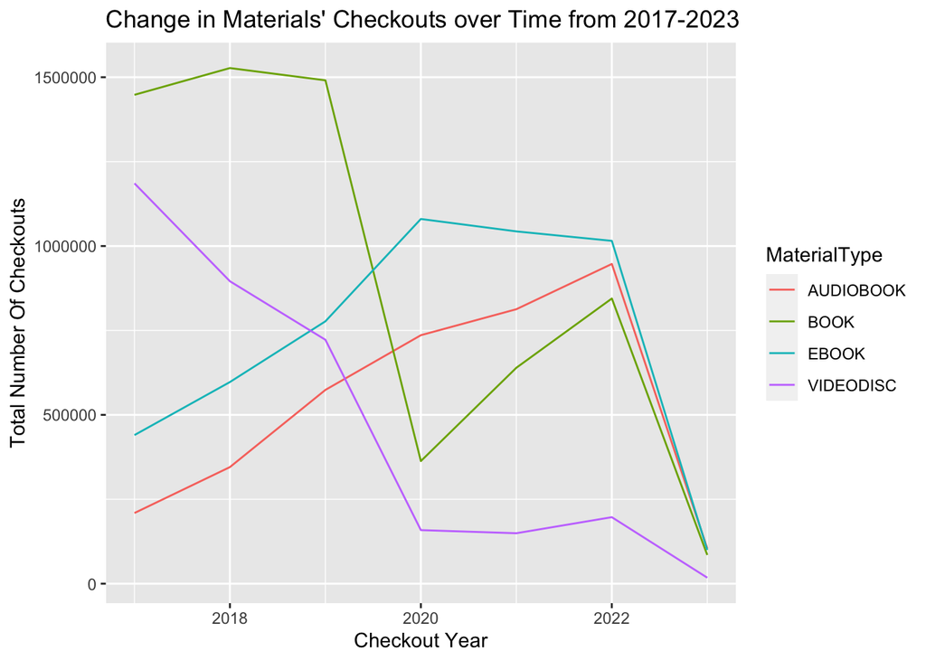

### Your Choice

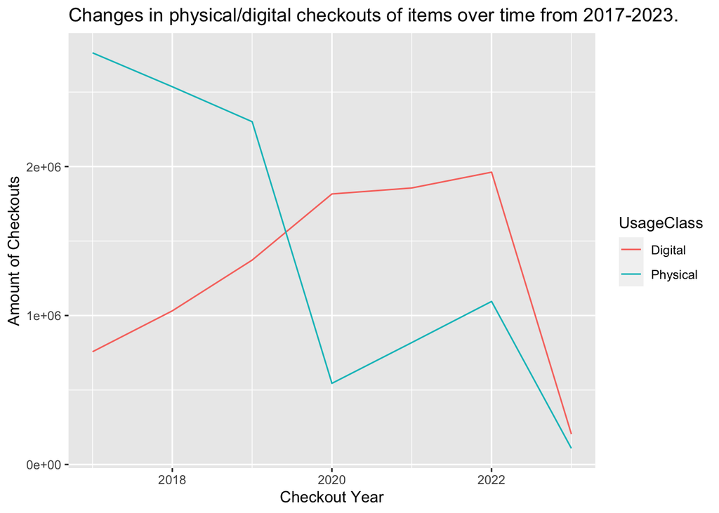